# Graphs in Python: Pie Charts *using explicitly defined axes in Matplotlib*

⇦ Back

# 1 The Basics

To make a pie chart in Python you need four things (and then another two things to display it properly):

- The Matplotlib package
  - Install this from the terminal with `python3.9 -m pip install matplotlib`
    - Replace `python3.9` with whatever version of Python you have
  - Import this package (specifically, the Pyplot sub-package) into your script under the alias `plt`
- Data to plot as a pie chart. This can be a list of numbers. These numbers don’t have to sum to 100 but, of course, they will be turned into percentages when Python represents them in the pie.
- Axes on which to plot, created with the `axes()` function and, in this example, assigned to the variable `ax`
- The `pie()` command from the Pyplot sub-package

The command `show()` will then display the pie chart and `close()` will close it afterwards (this is necessary if you want to continue plotting other charts and graphs):

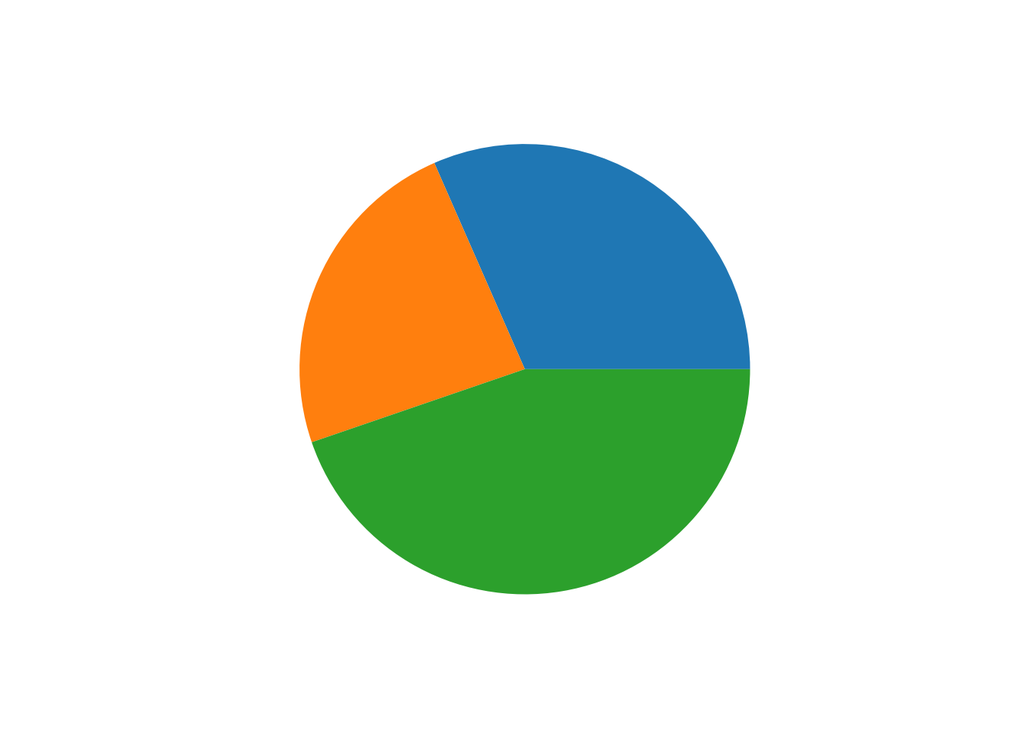

```python
import matplotlib.pyplot as plt

# Create data
data = [12, 9, 17]

# Plot
ax = plt.axes()
ax.pie(data)
plt.show()
plt.close()
```

## 1.1 Plot Title and Labels

Of course, this is a little empty. Fill in the chart with a title and labels:

- `set_title()` adds a title
  - The `fontsize` keyword argument can be used to change the font size
  - The special character “\n” creates a new line
- The `labels` parameter of the `pie()` function determines the labels

In this example, the data is create as a dictionary. The values are plotted in the pie chart and the keys are used as the labels:

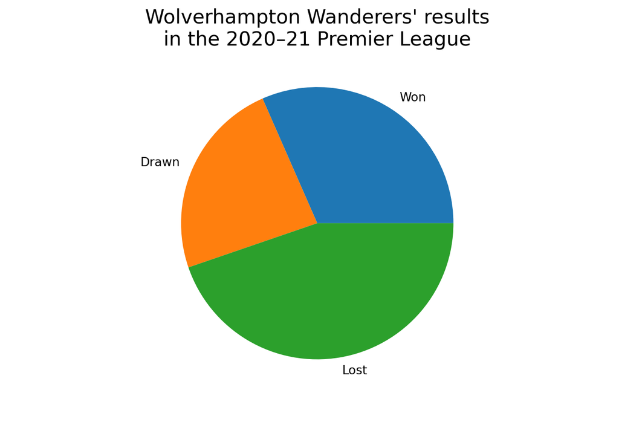

```python
import matplotlib.pyplot as plt

# Create data:
# Wolverhampton Wanderers' results in the 2020–21 Premier League
results = {'Won': 12, 'Drawn': 9, 'Lost': 17}

# Plot
ax = plt.axes()
ax.pie(results.values(), labels=results.keys())
ax.set_title("Wolverhampton Wanderers' results\nin the 2020–21 Premier League", fontsize=16)
plt.show()
plt.close()
```

## 1.2 Manual Annotations

Edit the labels to add more detail. If you are using special characters like “%” you will need to convert the labels to *raw strings* by prepending the letter “r”:

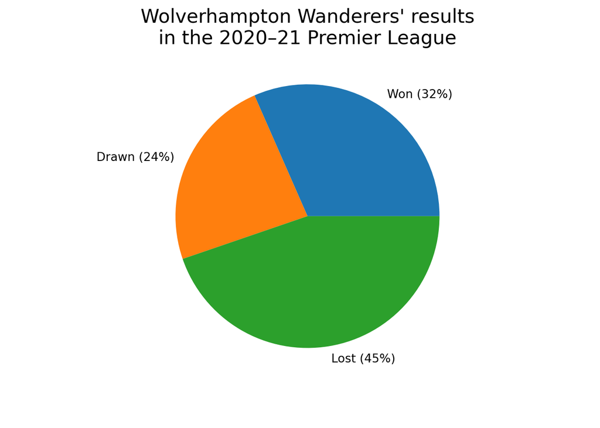

```python
import matplotlib.pyplot as plt

# Create data:
# Wolverhampton Wanderers' results in the 2020–21 Premier League
results = {r'Won (32%)': 12, r'Drawn (24%)': 9, r'Lost (45%)': 17}

# Plot
ax = plt.axes()
ax.pie(results.values(), labels=results.keys())
ax.set_title("Wolverhampton Wanderers' results\nin the 2020–21 Premier League", fontsize=16)
plt.show()
plt.close()
```

## 1.3 Automatic Annotations

A way of doing the above without having to hardcode the values in is provided by the `autopct` parameter. Set this equal to a formatting instruction such as would be used by an f-string (more about those here):

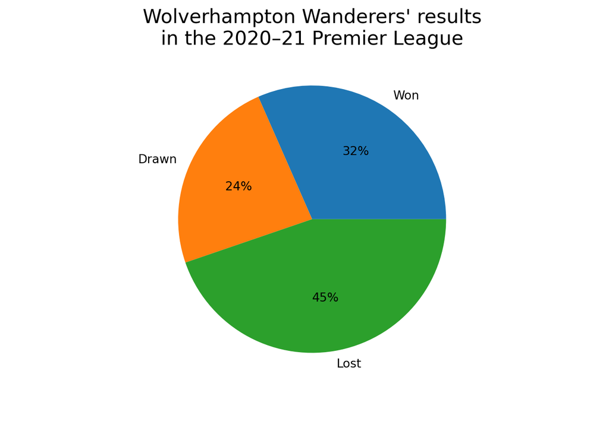

```python
import matplotlib.pyplot as plt

# Create data:
# Wolverhampton Wanderers' results in the 2020–21 Premier League
results = {'Won': 12, 'Drawn': 9, 'Lost': 17}

# Plot
ax = plt.axes()
ax.pie(results.values(), labels=results.keys(), autopct='%1.0f%%')
ax.set_title("Wolverhampton Wanderers' results\nin the 2020–21 Premier League", fontsize=16)
plt.show()
plt.close()
```

# 2 Colours

- The colours of the pie’s segments are customisable through the `colors` parameter
  - In this example, a list of hex codes is used
- To make the annotations more readable, a number of things can be done:
  - Increase their font size (together with the font size of the labels) with the `textprops` parameter, which takes a dictionary as its input
  - Add outlines:
    - The `patheffects` sub-module is needed
    - Access the annotations as objects by returning them from the `pie` function (in this example, they are assigned to the variable `autotexts`)
    - Loops through the annotations and use their `set_path_effects()` method to set a path around each of them
    - Make this path white to add contrast

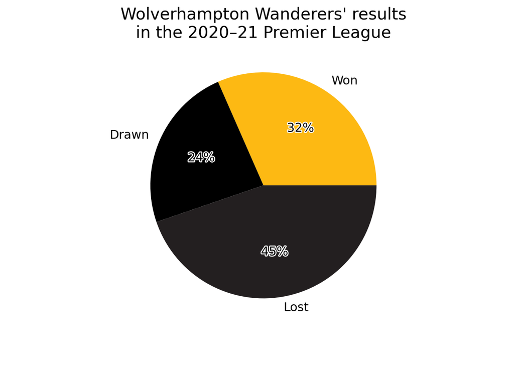

```python
import matplotlib.pyplot as plt
import matplotlib.patheffects as path_effects

# Create data:
# Wolverhampton Wanderers' results in the 2020–21 Premier League
results = {'Won': 12, 'Drawn': 9, 'Lost': 17}

# Custom colours
colors = ['#FDB913', '#000000', '#231F20']

# Plot
ax = plt.axes()
patches, texts, autotexts = ax.pie(
    results.values(), labels=results.keys(), autopct='%1.0f%%', colors=colors, textprops={'fontsize': 12}
)
for autotext in autotexts:
    autotext.set_path_effects(
        [path_effects.Stroke(linewidth=2, foreground='white'), path_effects.Normal()]
    )
ax.set_title("Wolverhampton Wanderers' results\nin the 2020–21 Premier League", fontsize=16)
plt.show()
plt.close()
```

# 3 Using Latex and Setting the Figure Size

The run commands (RCs), which are the instructions that get read first when the code is run, can be edited with Pyplot’s `rc()` command. These can be used to set the figure size and quality, to use Latex for the graph’s text and to add Latex packages:

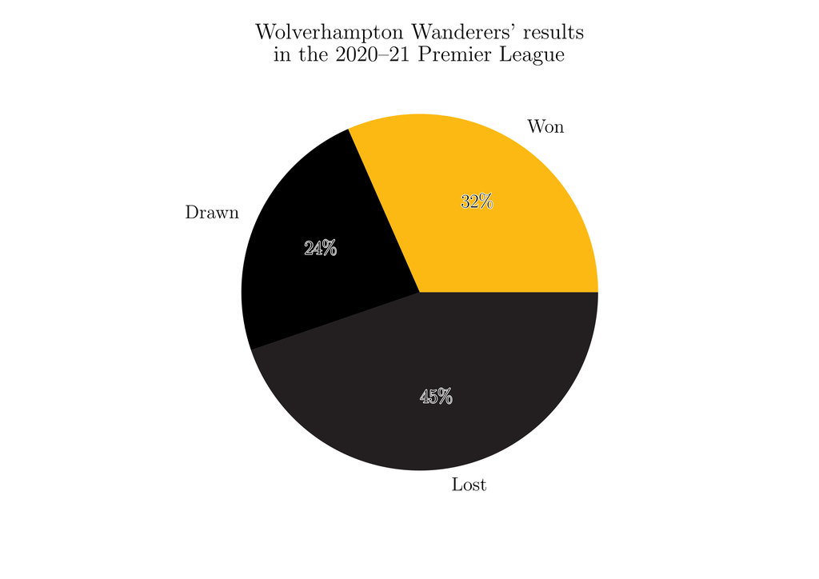

```python
import matplotlib.pyplot as plt
import matplotlib.patheffects as path_effects

# Settings
x = 5  # Want figures to be A6
plt.rc('figure', figsize=[46.82 * .5**(.5 * x), 33.11 * .5**(.5 * x)])
plt.rc('text', usetex=True)
plt.rc('font', family='serif')
plt.rc('text.latex', preamble=r'\usepackage{textgreek}')

# Create data:
# Wolverhampton Wanderers' results in the 2020–21 Premier League
results = {'Won': 12, 'Drawn': 9, 'Lost': 17}

# Custom colours
colors = ['#FDB913', '#000000', '#231F20']

# Plot
ax = plt.axes()
patches, texts, autotexts = ax.pie(
    results.values(), labels=results.keys(), autopct=r'%1.0f\%%', colors=colors, textprops={'fontsize': 14}
)
for autotext in autotexts:
    autotext.set_path_effects(
        [path_effects.Stroke(linewidth=1, foreground='white'), path_effects.Normal()]
    )
ax.set_title("Wolverhampton Wanderers' results\nin the 2020–21 Premier League", fontsize=16)
plt.show()
plt.close()
```

# 4 Save Plot

Finally, use `plt.savefig('name_of_plot.png')` to save the plot to your computer.

⇦ Back